# Exploratory Data analysis on White Wine Dataset

## by Deepak Das

#### The project is aimed at looking and finding deep insights of the white wine dataset. The report also aims in bringing us to a conclusion so as to what are the factors that affect the quality of wine.

[figure not shown]

```python
from IPython.display import HTML

HTML('''<script>
code_show=true;
function code_toggle() {
 if (code_show){
 $('div.input').hide();
 } else {
 $('div.input').show();
 }
 code_show = !code_show
}
$( document ).ready(code_toggle);
</script>
<form action="javascript:code_toggle()"><input type="submit" value="Click here to toggle on/off the raw code."></form>''')
```

```python
import pandas as pd
import numpy as np
import matplotlib.pyplot as plt
import seaborn as sns
%matplotlib inline
```

# Data description

#### The data is in csv format.In computing, a comma-separated values (CSV) file stores tabular data (numbers and text) in plain text. Each line of the file is a data record. Each record consists of one or more fields, separated by commas.

#### White wine is mainly from "white" grapes, which are green or yellow in colour, such as the Chardonnay, Sauvignon, and Riesling. Some white wine is also made from grapes with coloured skin, provided that the obtained wort is not stained.

#### Data are collected on 12 different properties of the wines one of which is Quality, based on sensory data, and the rest are on chemical properties of the wines including density, acidity, alcohol content etc. All chemical properties of wines are continuous variables. Quality is an ordinal variable with possible ranking from 1 (worst) to 10 (best). Each variety of wine is tasted by three independent tasters and the final rank assigned is the median rank given by the tasters.

# Attribute Information:

1. fixed acidity
2. volatile acidity
3. citric acid
4. residual sugar
5. chlorides
6. free sulfur dioxide
7. total sulfur dioxide
8. density
9. pH
10. sulphates
11. alcohol Output variable (based on sensory data):
12. quality (score between 0 and 10)

### Here we import the dataset and print the first 5 rows of the dataset using the head() function.

```python
df = pd.read_csv('https://raw.githubusercontent.com/Shreyas3108/May28thMLbatcj/master/wineQualityWhites.csv')
df.pop('Unnamed: 0')
df.head()
```

|  | fixed.acidity | volatile.acidity | citric.acid | residual.sugar | chlorides | free.sulfur.dioxide | total.sulfur.dioxide | density | pH | sulphates | alcohol | quality |
| --- | --- | --- | --- | --- | --- | --- | --- | --- | --- | --- | --- | --- |
| 0 | 7.0 | 0.27 | 0.36 | 20.7 | 0.045 | 45.0 | 170.0 | 1.0010 | 3.00 | 0.45 | 8.8 | 6 |
| 1 | 6.3 | 0.30 | 0.34 | 1.6 | 0.049 | 14.0 | 132.0 | 0.9940 | 3.30 | 0.49 | 9.5 | 6 |
| 2 | 8.1 | 0.28 | 0.40 | 6.9 | 0.050 | 30.0 | 97.0 | 0.9951 | 3.26 | 0.44 | 10.1 | 6 |
| 3 | 7.2 | 0.23 | 0.32 | 8.5 | 0.058 | 47.0 | 186.0 | 0.9956 | 3.19 | 0.40 | 9.9 | 6 |
| 4 | 7.2 | 0.23 | 0.32 | 8.5 | 0.058 | 47.0 | 186.0 | 0.9956 | 3.19 | 0.40 | 9.9 | 6 |

### Here we see the shape of the dataset

```python
df.shape
```

```
(4898, 12)
```

### Here we see the size of the dataset

```python
df.size
```

```
58776
```

### We see all the mathematical aspects of the data using the describe() function

```python
df.describe(include = 'all')
```

|  | fixed.acidity | volatile.acidity | citric.acid | residual.sugar | chlorides | free.sulfur.dioxide | total.sulfur.dioxide | density | pH | sulphates | alcohol | quality |
| --- | --- | --- | --- | --- | --- | --- | --- | --- | --- | --- | --- | --- |
| count | 4898.000000 | 4898.000000 | 4898.000000 | 4898.000000 | 4898.000000 | 4898.000000 | 4898.000000 | 4898.000000 | 4898.000000 | 4898.000000 | 4898.000000 | 4898.000000 |
| mean | 6.854788 | 0.278241 | 0.334192 | 6.391415 | 0.045772 | 35.308085 | 138.360657 | 0.994027 | 3.188267 | 0.489847 | 10.514267 | 5.877909 |
| std | 0.843868 | 0.100795 | 0.121020 | 5.072058 | 0.021848 | 17.007137 | 42.498065 | 0.002991 | 0.151001 | 0.114126 | 1.230621 | 0.885639 |
| min | 3.800000 | 0.080000 | 0.000000 | 0.600000 | 0.009000 | 2.000000 | 9.000000 | 0.987110 | 2.720000 | 0.220000 | 8.000000 | 3.000000 |
| 25% | 6.300000 | 0.210000 | 0.270000 | 1.700000 | 0.036000 | 23.000000 | 108.000000 | 0.991723 | 3.090000 | 0.410000 | 9.500000 | 5.000000 |
| 50% | 6.800000 | 0.260000 | 0.320000 | 5.200000 | 0.043000 | 34.000000 | 134.000000 | 0.993740 | 3.180000 | 0.470000 | 10.400000 | 6.000000 |
| 75% | 7.300000 | 0.320000 | 0.390000 | 9.900000 | 0.050000 | 46.000000 | 167.000000 | 0.996100 | 3.280000 | 0.550000 | 11.400000 | 6.000000 |
| max | 14.200000 | 1.100000 | 1.660000 | 65.800000 | 0.346000 | 289.000000 | 440.000000 | 1.038980 | 3.820000 | 1.080000 | 14.200000 | 9.000000 |

### Now here we check if there are any missing values.

### As we can see there are no missing values so no missing data to be handled.

```python
df.isnull().sum()
```

```
fixed.acidity           0
volatile.acidity        0
citric.acid             0
residual.sugar          0
chlorides               0
free.sulfur.dioxide     0
total.sulfur.dioxide    0
density                 0
pH                      0
sulphates               0
alcohol                 0
quality                 0
dtype: int64
```

# Univariate Analysis

#### Univariate analysis is the simplest form of analyzing data. “Uni” means “one”, so in other words your data has only one variable. It doesn't deal with causes or relationships (unlike regression) and it's major purpose is to describe; it takes data, summarizes that data and finds patterns in the data.The key pointers to the Univaraite analysis are to find out the outliers present in the data. We also tend to find the dsitribution of the data on the dataset which can further help us for the Bivaraite/Multivariate analysis.

## fixed.acidity - Histogram Plot

### From the following plot we can infer the following :-

1. The plot follows a normal distribution.
2. Count for fixed Acidity is high for the range(6-8 g/mL).
3. Outliers for the following plot is less.

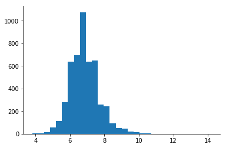

```python
plt.hist(x = 'fixed.acidity',data = df, bins=30)
plt.rc("axes.spines", top=False, right=False)
```

## fixed.acidity - Box Plot

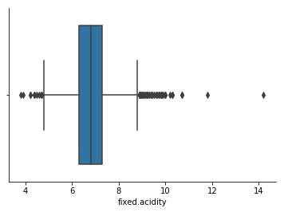

```python
sns.boxplot(df['fixed.acidity'])
sns.despine()
```

## volatile.acidity - Histogram Plot

### From the following plot we can infer the following :-

1. The following plot is skewed
2. Maximum no.of wines have volatile acidity less than 0.4(g/mL)
3. The distribution is continuous

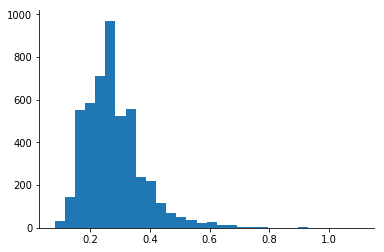

```python
plt.hist(x = 'volatile.acidity',data = df,bins = 30)
plt.rc("axes.spines", top=False, right=False)
```

## volatile.acidity - Box Plot

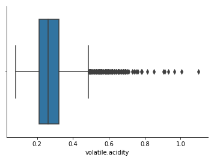

```python
sns.boxplot(df['volatile.acidity'])
sns.despine()
```

## citric.acid - Histogram Plot

### From the following plot we can infer the following :-

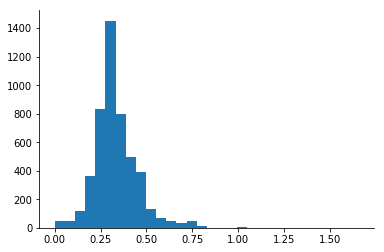

```python
plt.hist(x = 'citric.acid',data = df,bins = 30)
plt.rc("axes.spines", top=False, right=False)
```

## citirc.acid - Box Plot

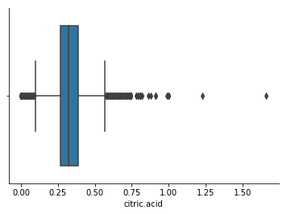

```python
sns.boxplot(df['citric.acid'])
sns.despine()
```

## residual.sugar - Histogram Plot

### From the following plot we can infer the following :-

1. The data is skewed towards right as seen form the plot
2. The count for residual sugars is high near 0.

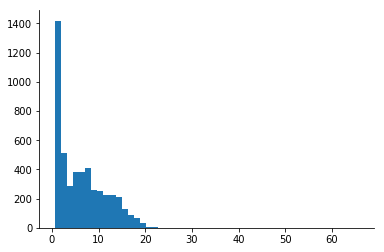

```python
plt.hist(x = 'residual.sugar',data = df,bins = 50)
plt.rc("axes.spines", top=False, right=False)
```

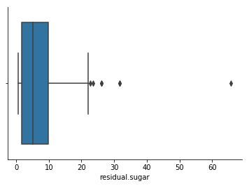

```python
sns.boxplot(df['residual.sugar'])
sns.despine()
```

## chlorides - Histogram Plot

### From the following plot we can infer the following :-

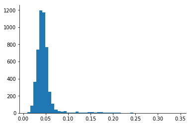

```python
plt.hist(x = 'chlorides',data = df,bins = 50)
plt.rc("axes.spines", top=False, right=False)
```

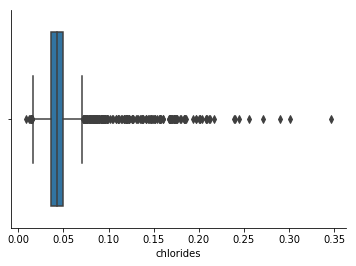

```python
sns.boxplot(df['chlorides'])
sns.despine()
```

## free.sulfur.dioxide - Histogram Plot

### From the following plot we can infer the following :-

1. There are outliers present in the data
2. The curves follows a normal distribution
3. The occurences of sulfur dioxide range from 20% to 50%

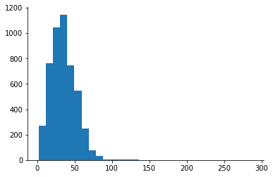

```python
plt.hist(x = 'free.sulfur.dioxide',data = df,bins = 30)
plt.rc("axes.spines", top=False, right=False)
```

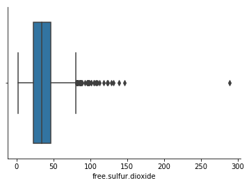

```python
sns.boxplot(df['free.sulfur.dioxide'])
sns.despine()
```

## total sulfur dioxide - Histogram Plot

### From the following plot we can infer the following :-

1. The plot follows a normal distribution
2. There are outliers present in the plot as seen from the boxplot
3. Most number of occurences are between 100 and 150

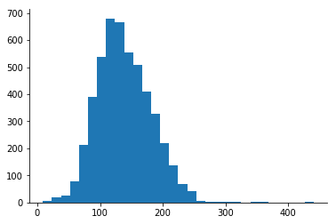

```python
plt.hist(x = 'total.sulfur.dioxide',data = df,bins = 30)
plt.rc("axes.spines", top=False, right=False)
```

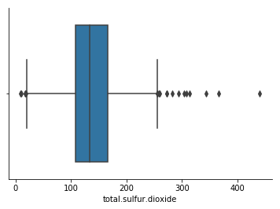

```python
sns.boxplot(df['total.sulfur.dioxide'])
sns.despine()
```

## density - Histogram Plot

### From the following plot we can infer the following :-

1. The curve seems to be normal
2. Number of outliers are less as seen form the box-plot
3. The denisty is high between the range 0.99 to 1.00

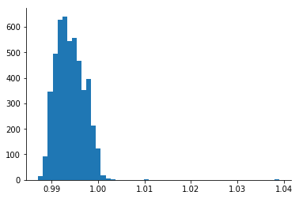

```python
plt.hist(x = 'density',data = df,bins = 50)
plt.rc("axes.spines", top=False, right=False)
```

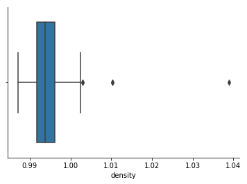

```python
sns.boxplot(df['density'])
sns.despine()
```

## pH - Histogram Plot

### From the following plot we can infer the following :-

1. The curve follows a normal distribution
2. There are outliers present as seen form the box-plot
3. The occurence of pH 3.2 is maximum i.e. most wines have pH of 3.2

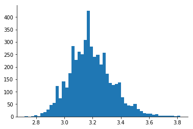

```python
plt.hist(x = 'pH',data = df,bins = 50)
plt.rc("axes.spines", top=False, right=False)
```

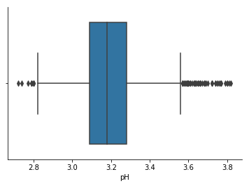

```python
sns.boxplot(df['pH'])
sns.despine()
```

## sulphates - Histogram Plot

### From the following plot we can infer the following :-

1. There are number of outliers present in the plot
2. The curve seems to be normal
3. Most wines have sulphate content of 0.4% to 0.6%

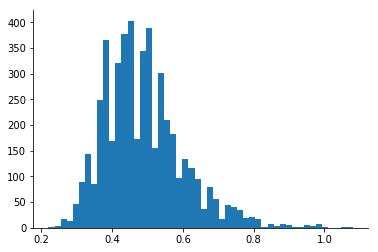

```python
plt.hist(x = 'sulphates',data = df,bins = 50)
plt.rc("axes.spines", top=False, right=False)
```

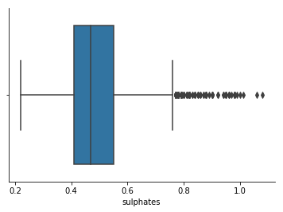

```python
sns.boxplot(df['sulphates'])
sns.despine()
```

## alcohol - Histogram Plot

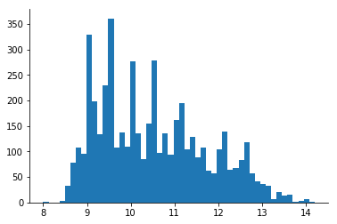

```python
plt.hist(x = 'alcohol',data = df,bins = 50)
plt.rc("axes.spines", top=False, right=False)
```

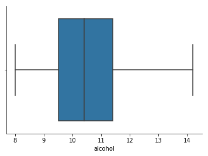

```python
sns.boxplot(df['alcohol'])
```

## quality - Histogram Plot

### From the following plot we can infer the following :-

1. We can infer that quality is a non-continuous data
2. Wine quality 6 has most number of samples
3. High quality wines rated 8 or higher are less in number
4. Most of the wine tasters were given medicore quality wines as compared to high quality wines.

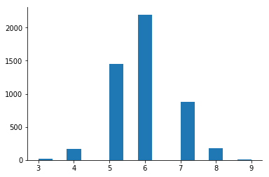

```python
plt.hist(x = 'quality',data = df,bins = 15)
plt.rc("axes.spines", top=False, right=False)
```

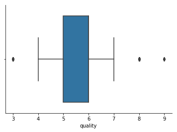

```python
sns.boxplot(df['quality'])
```